# week 6: multilevel models

multilevel tadpoles

```r
library(tidyverse)
library(psych)
library(cowplot)
library(patchwork)
library(here)
library(brms)
library(tidybayes)
```

## multilevel models

We’re starting our unit on multilevel models, which can be thought of as models that “remember” features of clusters of data as they learn about all the clusters. The model will pool information across clusters (e.g., our estimates about cluster A will be informed in part by clusters B, C, and D). This tends to improve estimates about each cluster. Here are some other benefits of multilevel modeling:

1. **improved estimates for repeated sampling.** If you try to fit a single-level model to these data, you’ll over- or under-fit the data.
2. **improved estimates for imbalance in sampling.** prevent over-sampled clusters from dominating inference, while also balancing the fact that larger clusters have more information.
3. **estimates of variation.** model variation explicitly!
4. **avoid averaging, retain variation.** averaging manufactures false confidence (artificially inflates precision) and introduces arbitrary data transformations.

Multilevel modeling should be your default approach.

## example: tadpoles

```r
data(reedfrogs, package = "rethinking")
d<- reedfrogs
str(d)
```

```
## 'data.frame':    48 obs. of  5 variables:
##  $ density : int  10 10 10 10 10 10 10 10 10 10 ...
##  $ pred    : Factor w/ 2 levels "no","pred": 1 1 1 1 1 1 1 1 2 2 ...
##  $ size    : Factor w/ 2 levels "big","small": 1 1 1 1 2 2 2 2 1 1 ...
##  $ surv    : int  9 10 7 10 9 9 10 9 4 9 ...
##  $ propsurv: num  0.9 1 0.7 1 0.9 0.9 1 0.9 0.4 0.9 ...
```

Each row is a tank. These tanks are examples of clusters. We’ll need to create an index variable for each tank.

```r
d$tank <- 1:nrow(d)
```

```r
d %>% count(density)
```

```
##   density  n
## 1      10 16
## 2      25 16
## 3      35 16
```

How would you fit a **single-level model** in which you estimate the survival rate (`surv`) of tadpoles separately for each tank?

- What is the distribution of the outcome variable?
- What is the formula?
- What is/are your prior(s)?

$$\begin{align*}
S_i &\sim \text{Binomial}(N_i, p_i) \\
\text{logit}(p_i) &= \alpha_{tank} \\
\alpha_j &\sim \text{Normal}(0,1.5)
\end{align*}$$

```r
m1 <-
  brm(data = d,
      family = binomial,
      surv | trials(density) ~ 0 + factor(tank),
      prior(normal(0, 1.5), class = b),
      iter = 2000, warmup = 1000, chains = 4, cores = 4,
      seed = 13,
      file = here("files/data/generated_data/m62.1"))
```

```r
m1
```

```
##  Family: binomial
##   Links: mu = logit
## Formula: surv | trials(density) ~ 0 + factor(tank)
##    Data: d (Number of observations: 48)
##   Draws: 4 chains, each with iter = 2000; warmup = 1000; thin = 1;
##          total post-warmup draws = 4000
##
## Regression Coefficients:
##              Estimate Est.Error l-95% CI u-95% CI Rhat Bulk_ESS Tail_ESS
## factortank1      1.72      0.75     0.36     3.28 1.00     6727     2922
## factortank2      2.39      0.87     0.85     4.24 1.00     5009     2249
## factortank3      0.75      0.63    -0.45     2.06 1.00     5975     2721
## factortank4      2.41      0.90     0.84     4.40 1.00     5413     2712
## factortank5      1.72      0.78     0.34     3.36 1.00     6346     2332
## factortank6      1.73      0.75     0.36     3.39 1.00     5673     2882
## factortank7      2.40      0.87     0.87     4.24 1.00     6013     2773
## factortank8      1.71      0.76     0.32     3.29 1.00     5652     2920
## factortank9     -0.37      0.61    -1.60     0.80 1.00     5643     2887
## factortank10     1.70      0.75     0.39     3.31 1.00     6262     2260
## factortank11     0.74      0.63    -0.46     2.05 1.00     6269     2696
## factortank12     0.39      0.63    -0.82     1.64 1.00     5644     2858
## factortank13     0.76      0.66    -0.46     2.12 1.00     5430     2848
## factortank14     0.01      0.61    -1.16     1.22 1.00     6416     3038
## factortank15     1.72      0.76     0.34     3.34 1.00     5830     2712
## factortank16     1.72      0.78     0.36     3.42 1.00     5907     2726
## factortank17     2.54      0.67     1.36     4.01 1.00     4795     2497
## factortank18     2.14      0.61     1.05     3.44 1.00     6054     2619
## factortank19     1.80      0.54     0.83     2.92 1.00     6042     3107
## factortank20     3.09      0.79     1.72     4.82 1.00     5402     2768
## factortank21     2.15      0.62     1.05     3.49 1.00     5870     2806
## factortank22     2.14      0.57     1.12     3.36 1.00     5687     2898
## factortank23     2.13      0.59     1.10     3.41 1.00     5338     3008
## factortank24     1.55      0.51     0.61     2.60 1.00     6469     3086
## factortank25    -1.11      0.45    -2.04    -0.26 1.00     5811     2806
## factortank26     0.08      0.38    -0.65     0.81 1.00     5386     3054
## factortank27    -1.54      0.49    -2.54    -0.63 1.00     5931     2981
## factortank28    -0.55      0.40    -1.36     0.20 1.00     5774     2862
## factortank29     0.07      0.40    -0.72     0.84 1.00     5880     2852
## factortank30     1.32      0.48     0.44     2.30 1.00     5203     2097
## factortank31    -0.72      0.42    -1.55     0.09 1.00     7194     3016
## factortank32    -0.39      0.42    -1.23     0.40 1.00     5849     2924
## factortank33     2.85      0.67     1.71     4.33 1.00     5415     2328
## factortank34     2.47      0.59     1.42     3.76 1.00     5835     2769
## factortank35     2.46      0.57     1.46     3.68 1.00     5369     2660
## factortank36     1.91      0.49     1.02     2.97 1.00     6166     2748
## factortank37     1.91      0.49     1.00     2.93 1.00     6123     2860
## factortank38     3.37      0.77     2.05     5.04 1.00     5313     2355
## factortank39     2.46      0.58     1.43     3.72 1.00     6008     2835
## factortank40     2.16      0.53     1.21     3.32 1.00     5945     2463
## factortank41    -1.91      0.49    -2.95    -1.02 1.00     6293     2323
## factortank42    -0.63      0.35    -1.32     0.04 1.00     6646     3016
## factortank43    -0.51      0.34    -1.19     0.16 1.00     5326     3035
## factortank44    -0.39      0.33    -1.05     0.24 1.00     6226     3190
## factortank45     0.52      0.35    -0.15     1.22 1.00     7301     2643
## factortank46    -0.63      0.35    -1.34     0.04 1.00     5798     2948
## factortank47     1.91      0.49     1.03     2.91 1.00     5941     2893
## factortank48    -0.07      0.34    -0.74     0.59 1.00     7503     2958
##
## Draws were sampled using sampling(NUTS). For each parameter, Bulk_ESS
## and Tail_ESS are effective sample size measures, and Rhat is the potential
## scale reduction factor on split chains (at convergence, Rhat = 1).
```

Now we’ll consider the multilevel alternative.

$$\begin{align*}
S_i &\sim \text{Binomial}(N_i, p_i) \\
\text{logit}(p_i) &= \alpha_{tank} \\
\alpha_j &\sim \text{Normal}(\bar{\alpha},\sigma) \\
\bar{\alpha} &\sim \text{Normal}(0, 1.5) \\
\sigma &\sim \text{Exponential}(1)
\end{align*}$$

```r
m2 <-
  brm(data = d,
      family = binomial,
      surv | trials(density) ~ 1 + (1 | tank),
      prior = c( prior(normal(0, 1.5), class = Intercept), # alpha bar
                 prior(exponential(1), class = sd)),       # sigma
      iter = 2000, warmup = 1000, chains = 4, cores = 4,
      seed = 13,
      file = here("files/data/generated_data/m62.2"))
```

The syntax for the varying effects follows the `lme4` style, `( <varying parameter(s)> | <grouping variable(s)> )`. In this case `(1 | tank)` indicates only the intercept, 1, varies by tank. The extent to which parameters vary is controlled by the prior, `prior(exponential(1), class = sd)`, which is parameterized in the standard deviation metric.

Compare our two models.

```r
m1 <- add_criterion(m1, "waic")
m2 <- add_criterion(m2, "waic")

w <- loo_compare(m1, m2, criterion = "waic")

print(w, simplify = F)
```

```
##    elpd_diff se_diff elpd_waic se_elpd_waic p_waic se_p_waic waic   se_waic
## m2    0.0       0.0   -99.7       3.7         20.6    0.8     199.4    7.3
## m1   -7.3       1.8  -107.0       2.3         25.3    1.2     214.0    4.7
```

## exercise

1. Fit the multilevel tadpoles model.
2. In the video lecture, McElreath demonstrates that cross-validation can be used to determine that an appropriate prior for sigma is about 1.8. Recreate this demonstration. (Start with just 3 values of $\sigma$ so you can finish this in class. You can update later with more values for fun.)

### solution

```r
sigma_seq <- exp(seq(from=log(0.1), to=log(5), len=20))
waic_values <- numeric(length(sigma_seq))
loo_values <- numeric(length(sigma_seq))

for(i in 1:length(sigma_seq)) {
  sigma_value <- sigma_seq[i]
  cat("Fitting model", i, "with prior rate =", sigma_value, "\n")

  # Create the prior with the specific numeric value
  my_prior <- c(
    set_prior("normal(0, 1.5)", class = "Intercept"),
    set_prior(paste0("exponential(", sigma_value, ")"), class = "sd")
  )

  # Fit the model with this prior
  model <- brm(
    data = d,
    family = binomial,
    surv | trials(density) ~ 1 + (1 | tank),
    prior = my_prior,
    iter = 1000, warmup = 500, chains = 4, cores = 4,
    seed = 13,
    file = here(paste0("files/data/generated_data/m62_prior_", i))
  )

  # Calculate WAIC
  model <- add_criterion(model, "waic")
  waic_values[i] <- model$criteria$waic$estimates["waic", "Estimate"]
  # Calculate WAIC
  model <- add_criterion(model, "loo")
  loo_values[i] <- model$criteria$loo$estimates["elpd_loo", "Estimate"]


  # Optional: clean up to save memory
  rm(model)
  gc()
}
```

```
## Fitting model 1 with prior rate = 0.1
## Fitting model 2 with prior rate = 0.1228625
## Fitting model 3 with prior rate = 0.150952
## Fitting model 4 with prior rate = 0.1854635
## Fitting model 5 with prior rate = 0.2278651
## Fitting model 6 with prior rate = 0.2799609
## Fitting model 7 with prior rate = 0.3439671
## Fitting model 8 with prior rate = 0.4226066
## Fitting model 9 with prior rate = 0.5192252
## Fitting model 10 with prior rate = 0.6379333
## Fitting model 11 with prior rate = 0.783781
## Fitting model 12 with prior rate = 0.9629732
## Fitting model 13 with prior rate = 1.183133
## Fitting model 14 with prior rate = 1.453628
## Fitting model 15 with prior rate = 1.785964
## Fitting model 16 with prior rate = 2.19428
## Fitting model 17 with prior rate = 2.695948
## Fitting model 18 with prior rate = 3.312311
## Fitting model 19 with prior rate = 4.069589
## Fitting model 20 with prior rate = 5
```

### solution

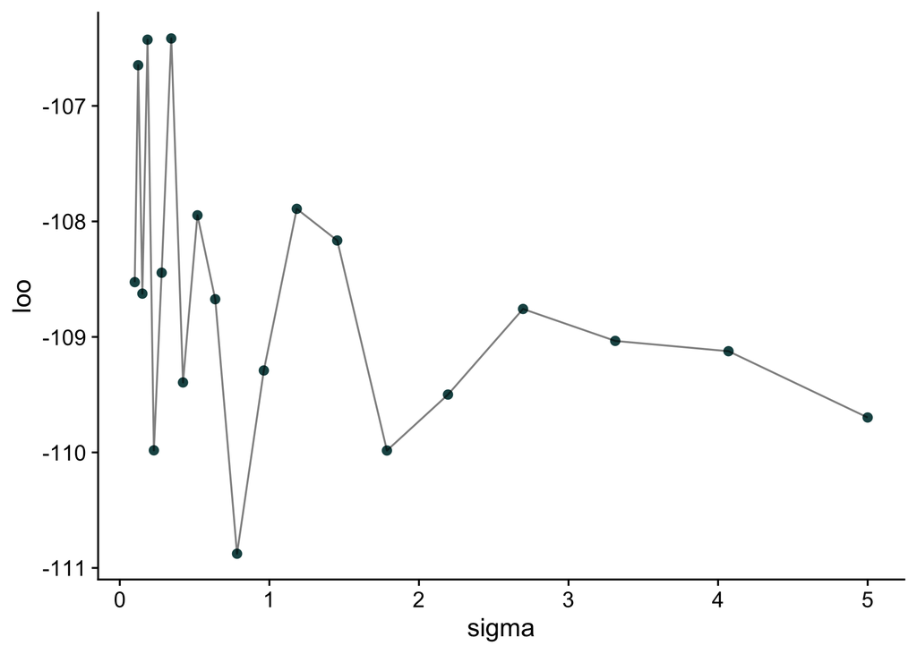

```r
data.frame(
  sigma = sigma_seq,
  loo = loo_values
) %>%
  ggplot( aes( x=sigma, y=loo )) +
  geom_point( size=2, color = "#1c5253" ) +
  geom_line(alpha = .5)
```

### exercise

Check your trace plots to evaluate whether your chains have mixed appropriately.

### solution

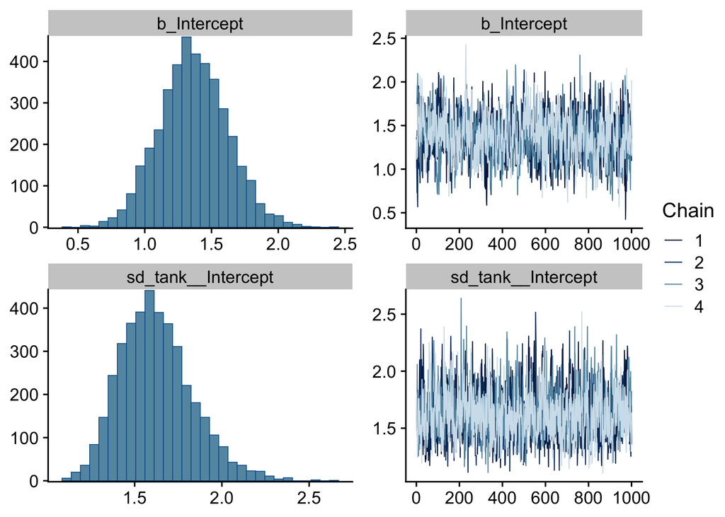

```r
plot(m2)
```

Here’s an additional packages – `bayesplot` – to help you visualize chains.

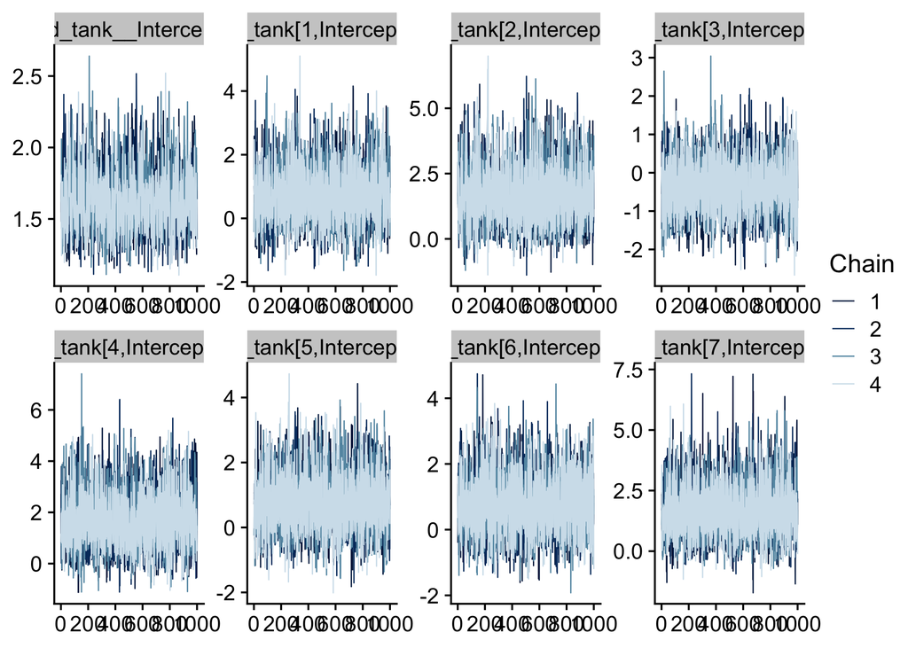

```r
library(bayesplot)
as_draws_df(m2) %>%
  select(contains("tank"), .chain) %>%
  select(1:8, chain=.chain) %>%
  mcmc_trace(facet_args = list(ncol=4))
```

Here’s an additional packages – `bayesplot` – to help you visualize chains.

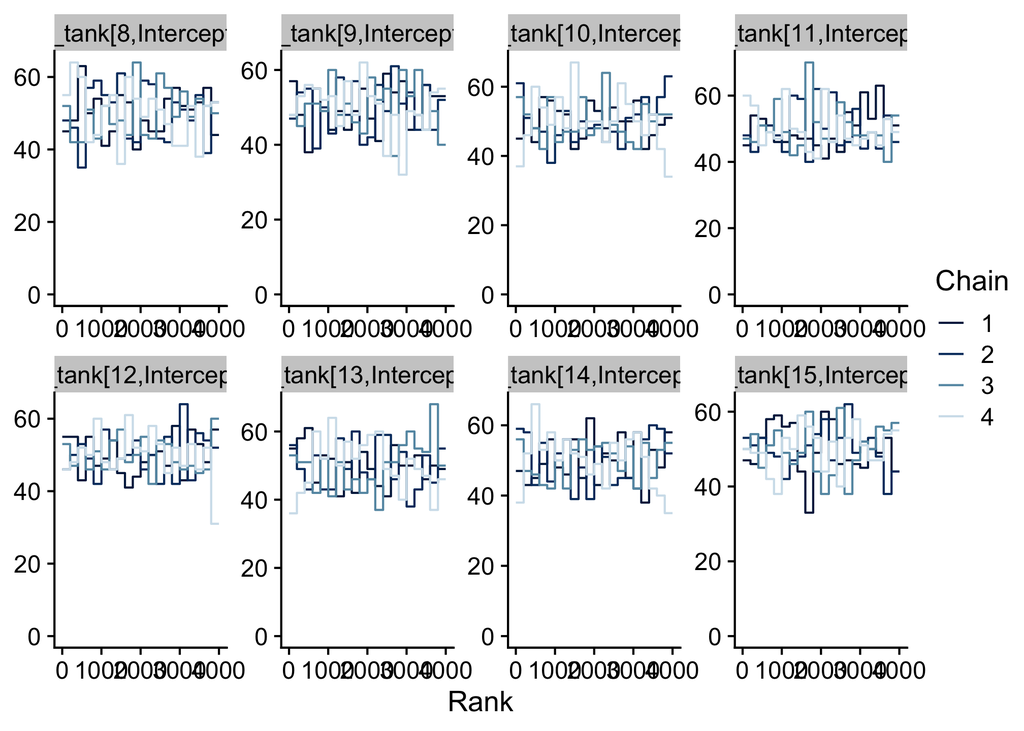

```r
library(bayesplot)

as_draws_df(m2) %>%
  select(contains("tank"), .chain) %>%
  select(9:16, chain = .chain) %>%
  mcmc_rank_overlay(facet_args = list(ncol=4, scales="free"))
```

```r
m2
```

```
##  Family: binomial
##   Links: mu = logit
## Formula: surv | trials(density) ~ 1 + (1 | tank)
##    Data: d (Number of observations: 48)
##   Draws: 4 chains, each with iter = 2000; warmup = 1000; thin = 1;
##          total post-warmup draws = 4000
##
## Multilevel Hyperparameters:
## ~tank (Number of levels: 48)
##               Estimate Est.Error l-95% CI u-95% CI Rhat Bulk_ESS Tail_ESS
## sd(Intercept)     1.63      0.21     1.27     2.09 1.01     1094     1936
##
## Regression Coefficients:
##           Estimate Est.Error l-95% CI u-95% CI Rhat Bulk_ESS Tail_ESS
## Intercept     1.37      0.26     0.88     1.88 1.00      670     1109
##
## Draws were sampled using sampling(NUTS). For each parameter, Bulk_ESS
## and Tail_ESS are effective sample size measures, and Rhat is the potential
## scale reduction factor on split chains (at convergence, Rhat = 1).
```

Our summary output doesn’t show us the individual intercepts for each tank. No worries – let’s draw from our posterior!

```r
post <- as_draws_df(m2)

str(post)
```

```
## draws_df [4,000 × 56] (S3: draws_df/draws/tbl_df/tbl/data.frame)
##  $ b_Intercept         : num [1:4000] 1.27 1.02 1.28 1.44 1.33 ...
##  $ sd_tank__Intercept  : num [1:4000] 1.7 1.55 1.75 1.7 1.47 ...
##  $ Intercept           : num [1:4000] 1.27 1.02 1.28 1.44 1.33 ...
##  $ r_tank[1,Intercept] : num [1:4000] 1.211 2.58 0.217 1.898 1.411 ...
##  $ r_tank[2,Intercept] : num [1:4000] 1.64 1.76 1.19 2.31 3.99 ...
##  $ r_tank[3,Intercept] : num [1:4000] -0.55592 -0.18093 0.00559 -0.61033 -0.08098 ...
##  $ r_tank[4,Intercept] : num [1:4000] 2.729 0.896 2.576 0.793 2.261 ...
##  $ r_tank[5,Intercept] : num [1:4000] 1.053 1.075 0.858 0.59 -0.347 ...
##  $ r_tank[6,Intercept] : num [1:4000] -0.4 0.108 1.388 0.124 1.565 ...
##  $ r_tank[7,Intercept] : num [1:4000] 2.302 2.346 0.905 2.419 1.822 ...
##  $ r_tank[8,Intercept] : num [1:4000] 1.377 1.097 0.416 1.486 -1.092 ...
##  $ r_tank[9,Intercept] : num [1:4000] -1.326 0.306 -3.024 -0.159 -1.421 ...
##  $ r_tank[10,Intercept]: num [1:4000] 1.202 2.468 0.906 0.848 0.471 ...
##  $ r_tank[11,Intercept]: num [1:4000] -1.31 0.611 -1.164 0.585 0.397 ...
```

[output cut: 42 more lines]

Each of the tank-specific intercepts here represent how the tank intercept deviates from the grand mean (`b_Intercept`). We also have to remember that these values are in logits. If we want to see these as probabities, we have to back-transform.

```r
modeled_prop = post %>%
  select(b_Intercept, starts_with("r_tank")) %>%
  pivot_longer(-b_Intercept, values_to = "logit") %>%
  mutate(logit = logit + b_Intercept,
    prob = inv_logit_scaled(logit)) %>%
  group_by(name)

modeled_prop %>%
  median_qi(prob)
```

```
## # A tibble: 48 × 7
##    name                  prob .lower .upper .width .point .interval
##    <chr>                <dbl>  <dbl>  <dbl>  <dbl> <chr>  <chr>
##  1 r_tank[1,Intercept]  0.890  0.655  0.982   0.95 median qi
##  2 r_tank[10,Intercept] 0.888  0.659  0.981   0.95 median qi
##  3 r_tank[11,Intercept] 0.726  0.432  0.911   0.95 median qi
##  4 r_tank[12,Intercept] 0.639  0.349  0.866   0.95 median qi
##  5 r_tank[13,Intercept] 0.727  0.445  0.917   0.95 median qi
##  6 r_tank[14,Intercept] 0.549  0.264  0.809   0.95 median qi
##  7 r_tank[15,Intercept] 0.889  0.645  0.984   0.95 median qi
##  8 r_tank[16,Intercept] 0.889  0.652  0.981   0.95 median qi
##  9 r_tank[17,Intercept] 0.945  0.827  0.991   0.95 median qi
## 10 r_tank[18,Intercept] 0.912  0.772  0.979   0.95 median qi
## # ℹ 38 more rows
```

## exercise

We’ll recreate another figure of McElreath’s that shows the relationship between the observed probability of survival for each tank and the predicted probabilty. Here’s what your figure should have:

1. Survival probability (y-axis) for each tank (x-axis)
2. Empty circular points representing the model’s estimated probability for each tank
3. Filled teal/green points showing the observed proportions in each tank
4. A horizontal line showing the average proportion across all tanks

OPTIONAL

5. Vertical dashed lines separating the three tank size categories
6. Text labels for each tank size group
7. Something to indicate the posterior *distribution* of survival for **each** tank.

## solution

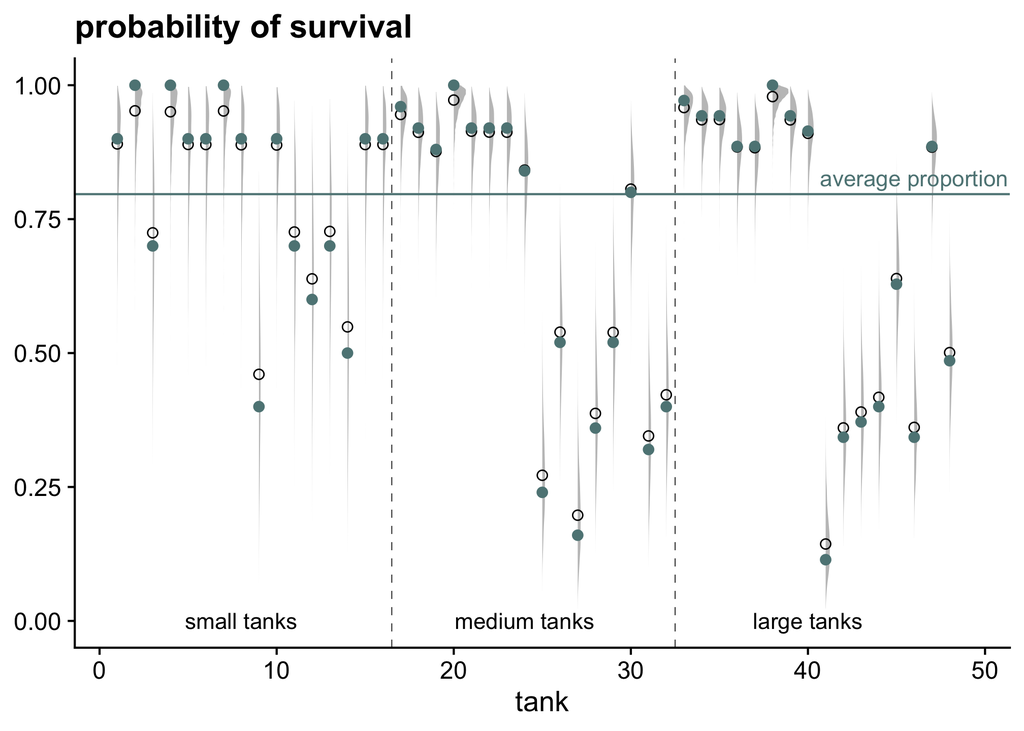

```r
observed_prop = d %>%
  mutate(prob = surv/density)

modeled_prop_m = modeled_prop %>%
  median_qi(prob) %>%
  mutate( tank = str_extract(name, "[0-9]{1,2}"),
          tank = as.numeric(tank) )

avg_prop = inv_logit_scaled(mean(post$b_Intercept))

modeled_prop %>%
  mutate( tank = str_extract(name, "[0-9]{1,2}"),
          tank = as.numeric(tank) ) %>%
  ggplot( aes(x=tank, y=prob) ) +
  stat_slab(alpha=.7) +
  geom_point( data = modeled_prop_m,
              shape = 1,
              size=2) +
  geom_point(data = observed_prop,
              color = "#5e8485",
             size=2) +
  # lines separating small, med, and large tanks
  geom_vline(xintercept = c(16.5, 32.5),
             linetype = "dashed",
             linewidth = 1/4, color = "grey25") +
  geom_hline(yintercept = avg_prop, linewidth = .5, color = "#5e8485") +
  annotate(geom = "text",
           x = c(8, 16 + 8, 32 + 8), y = 0,
           label = c("small tanks", "medium tanks", "large tanks")) +
  annotate(geom = "text",
           x = 46, y = avg_prop+.03,
           label = c("average proportion"),
           color = "#5e8485", ) +
  labs(
    x="tank",
    y=NULL,
    title="probability of survival"
  )
```